```python
import matplotlib.pyplot as plt
import numpy as np
```

# I Gradient descent

## Data set 01

| Size (1000 sqft) | Price (1000s of dollars) |
| --- | --- |
| 1 | 300 |
| 2 | 500 |

```python
x_train = np.array([1, 2])
y_train = np.array([300, 500])

print("Train set 01:")
print("Train X: {}".format(x_train))
print("Train Y: {}".format(y_train))
```

```
Train set 01:
Train X: [1 2]
Train Y: [300 500]
```

## 01 Computing cost

The equation for cost with one variable is: $$J(w,b) = \frac{1}{2m} \sum\limits_{i = 0}^{m-1} (f_{w,b}(x^{(i)}) - y^{(i)})^2 \tag{1}$$

where $$f_{w,b}(x^{(i)}) = wx^{(i)} + b \tag{2}$$

- $f_{w,b}(x^{(i)})$ is our prediction for example $i$ using parameters $w,b$.
- $(f_{w,b}(x^{(i)}) -y^{(i)})^2$ is the squared difference between the target value and the prediction.
- These differences are summed over all the $m$ examples and divided by `2m` to produce the cost, $J(w,b)$.

### (a) Computing $f(w, b)$

```python
def predict_y(w, b, x):
    return w * x + b
```

### (b) Computing $J(w, b)$

```python
def computing_cost(w, b, x, y):
    return np.sum((predict_y(w, b, x) - y) ** 2) / (2 * x.shape[0])
```

```python
print(computing_cost(220, 100, x_train, y_train))
```

```
500.0
```

### (c) Plot

```
Lowest cost: 0.0
w when cost is lowest: 200
```

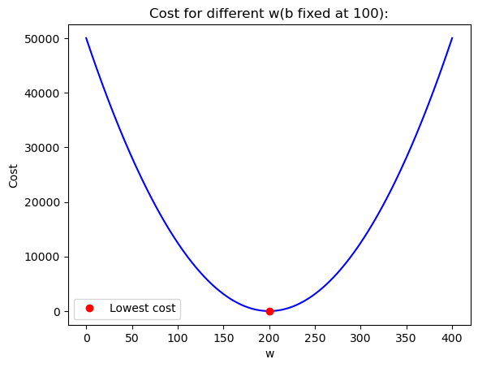

```python
w = np.arange(0, 401)
b = 100

cost = np.zeros([401,])
for i in range(w.shape[0]):
    cost[i] = computing_cost(w[i], b, x_train, y_train)

mininum_cost = np.min(cost)
mininum_cost_index = np.argmin(cost)

print("Lowest cost: {}".format(mininum_cost))
print("w when cost is lowest: {}".format(mininum_cost_index))

plt.plot(w, cost, color = 'blue')
plt.plot(mininum_cost_index, mininum_cost, 'ro', label = 'Lowest cost')
plt.title("Cost for different w(b fixed at 100):")
plt.xlabel('w')
plt.ylabel('Cost')
plt.legend()
plt.show()
```

## 02 Gradient descent

In lecture, *gradient descent* was described as:

$$\begin{align*} \text{repeat}&\text{ until convergence:} \; \lbrace \newline \; w &= w - \alpha \frac{\partial J(w,b)}{\partial w} \tag{3} \; \newline b &= b - \alpha \frac{\partial J(w,b)}{\partial b} \newline \rbrace \end{align*}$$

where, parameters $w$, $b$ are updated **simultaneously**.
The gradient is defined as: $$ \begin{align} \frac{\partial J(w,b)}{\partial w} &= \frac{1}{m} \sum\limits_{i = 0}^{m-1} ((f_{w,b}(x^{(i)}) - y^{(i)})x^{(i)}) \tag{4}\\ \frac{\partial J(w,b)}{\partial b} &= \frac{1}{m} \sum\limits_{i = 0}^{m-1} (f_{w,b}(x^{(i)}) - y^{(i)}) \tag{5}\\ \end{align} $$

Here *simultaniously* means that you calculate the partial derivatives for all the parameters before updating any of the parameters.

### (a) Compute $\frac{\partial (w, b)}{\partial w}$, $\frac{\partial (w, b)}{\partial b}$

```python
def compute_gradient(w, b, x, y):
    dj_dw = np.sum((predict_y(w, b, x) - y) * x) / x.shape[0]
    dj_db = np.sum(predict_y(w, b, x) - y) / x.shape[0]

    return dj_dw, dj_db
```

```python
print(x_train, y_train)
compute_gradient(0, 0, x_train, y_train)
```

```
[1 2] [300 500]
```

```
(-650.0, -400.0)
```

### (b) Gradient descent

```python
def gradient_descent(x, y, w, b, alpha, num_iters):
    j_history = [] # history values of cost function
    p_history = [] # history values of w and b
    for i in range(num_iters):
        dj_dw, dj_db = compute_gradient(w, b, x, y)
        w = w - alpha * dj_dw
        b = b - alpha * dj_db
        cost_n = computing_cost(w, b, x, y)

        if (i < 100000):
            j_history.append(cost_n)
            p_history.append([w, b])

        if (i % 1000 == 0):
            print(f"Iteration {i:4} - Cost: {cost_n:0.4e} - w: {dj_dw:0.4e} - b: {dj_db:0.4e}")
    return w, b, np.array(j_history), np.array(p_history)
```

### (c) Test gradient descent

```python
# initialize parameters
w_init = 0
b_init = 0
# some gradient descent settings
iterations = 10000
tmp_alpha = 1.0e-2
# run gradient descent
w_final, b_final, J_hist, p_hist = gradient_descent(x_train ,y_train, w_init, b_init, tmp_alpha, iterations)
print(f"(w,b) found by gradient descent: ({w_final:8.4f},{b_final:8.4f})")
```

```
Iteration    0 - Cost: 7.9275e+04 - w: -6.5000e+02 - b: -4.0000e+02
Iteration 1000 - Cost: 3.4125e+00 - w: -3.7123e-01 - b: 6.0066e-01
Iteration 2000 - Cost: 7.9290e-01 - w: -1.7894e-01 - b: 2.8953e-01
Iteration 3000 - Cost: 1.8423e-01 - w: -8.6255e-02 - b: 1.3956e-01
Iteration 4000 - Cost: 4.2805e-02 - w: -4.1577e-02 - b: 6.7273e-02
Iteration 5000 - Cost: 9.9458e-03 - w: -2.0041e-02 - b: 3.2427e-02
Iteration 6000 - Cost: 2.3109e-03 - w: -9.6604e-03 - b: 1.5631e-02
Iteration 7000 - Cost: 5.3694e-04 - w: -4.6566e-03 - b: 7.5345e-03
Iteration 8000 - Cost: 1.2476e-04 - w: -2.2446e-03 - b: 3.6318e-03
Iteration 9000 - Cost: 2.8987e-05 - w: -1.0820e-03 - b: 1.7506e-03
(w,b) found by gradient descent: (199.9929,100.0116)
```

### (d) Plot for the first 100 iterations

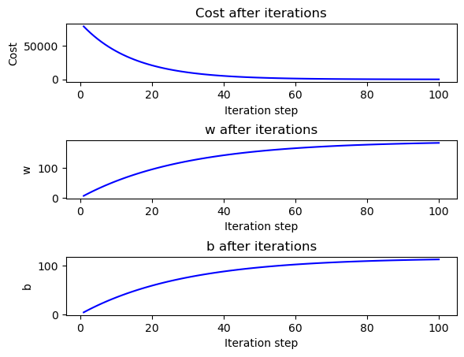

```python
# xaxis = np.arange(1, len(J_hist) + 1)
xaxis = np.arange(1, 101)

plt.figure()
plt.subplots_adjust(hspace = 1)

plt.subplot(3, 1, 1)
plt.title("Cost after iterations")
plt.xlabel("Iteration step")
plt.ylabel("Cost")
plt.plot(xaxis, J_hist[:100], color = 'blue')

plt.subplot(3, 1, 2)
plt.title("w after iterations")
plt.xlabel("Iteration step")
plt.ylabel("w")
plt.plot(xaxis, p_hist[:100, 0], color = 'blue')

plt.subplot(3, 1, 3)
plt.title("b after iterations")
plt.xlabel("Iteration step")
plt.ylabel("b")
plt.plot(xaxis, p_hist[:100, 1], color = 'blue')

plt.show()
```

# II Multiple Variable Linear Regression

## 01 Notation

| General Notation | Description | Python (if applicable) |  |
| --- | --- | --- | --- |
| $a$ | scalar, non bold |  |  |
| $\mathbf{a}$ | vector, bold |  |  |
| $\mathbf{A}$ | matrix, bold capital |  |  |
| **Regression** |  |  |  |
| $\mathbf{X}$ | training example maxtrix | `X_train` |  |
| $\mathbf{y}$ | training example targets | `y_train` |  |
| $\mathbf{x}^{(i)}$, $y^{(i)}$ | $i_{th}$Training Example | `X[i]`, `y[i]` |  |
| m | number of training examples | `m` |  |
| n | number of features in each example | `n` |  |
| $\mathbf{w}$ | parameter: weight, | `w` |  |
| $b$ | parameter: bias | `b` |  |
| $f_{\mathbf{w},b}(\mathbf{x}^{(i)})$ | The result of the model evaluation at $\mathbf{x^{(i)}}$ parameterized by $\mathbf{w},b$: $f_{\mathbf{w},b}(\mathbf{x}^{(i)}) = \mathbf{w} \cdot \mathbf{x}^{(i)}+b$ | `f_wb` |  |

## 02 Problem Statement

You will use the motivating example of housing price prediction. The training dataset contains three examples with four features (size, bedrooms, floors and, age) shown in the table below. Note that, unlike the earlier labs, size is in sqft rather than 1000 sqft. This causes an issue, which you will solve in the next lab!

| Size (sqft) | Number of Bedrooms | Number of floors | Age of Home | Price (1000s dollars) |
| --- | --- | --- | --- | --- |
| 2104 | 5 | 1 | 45 | 460 |
| 1416 | 3 | 2 | 40 | 232 |
| 852 | 2 | 1 | 35 | 178 |

You will build a linear regression model using these values so you can then predict the price for other houses. For example, a house with 1200 sqft, 3 bedrooms, 1 floor, 40 years old.

```python
X_train = np.array([[2104, 5, 1, 45], [1416, 3, 2, 40], [852, 2, 1, 35]])
y_train = np.array([460, 232, 178])
```

$\mathbf{w}$ is a vector with $n$ elements.

$$\mathbf{w} = \begin{pmatrix} w_0 \\ w_1 \\ \cdots\\ w_{n-1} \end{pmatrix} $$

$b$ is a scalar parameter.

```python
b_init = 785.1811367994083
w_init = np.array([ 0.39133535, 18.75376741, -53.36032453, -26.42131618])
print(f"w_init shape: {w_init.shape}, b_init type: {type(b_init)}")
```

```
w_init shape: (4,), b_init type: <class 'float'>
```

**For multiple-variable prediction, we should use dot product of vectors.**

```python
np.dot(X_train, w_init)
```

```
array([-325.18113918, -553.18113843, -607.18113781])
```

### (a) Computing $f(w, b)$

```python
def predict_y_multiple(w, b, x): # w and x are both vectors
    return np.dot(x, w) + b
```

```python
predict_y_multiple(w_init, b_init, X_train[0, :])
```

```
459.9999976194083
```

### (b) Computing $J(w, b)$

```python
def computing_cost_multiple(w, b, x, y):
    return np.sum((predict_y_multiple(w, b, x) - y) ** 2) / (2 * x.shape[0])
```

```python
computing_cost_multiple(w_init, b_init, X_train, y_train)
```

```
1.5578903428073909e-12
```

### (c) Compute $\frac{\partial (w, b)}{\partial w}$, $\frac{\partial (w, b)}{\partial b}$

```python
def compute_gradient_multiple(w, b, x, y):
    dj_dw = 0
    for i in range(X_train.shape[0]):
        dj_dw_i = (predict_y_multiple(w, b, x[i]) - y[i]) * x[i] / x.shape[0]
        dj_dw += dj_dw_i
    dj_db = np.sum(predict_y_multiple(w, b, x) - y) / x.shape[0]

    return dj_dw, dj_db
compute_gradient_multiple(w_init, b_init, X_train, y_train)
```

```
(array([-2.72623574e-03, -6.27197255e-06, -2.21745574e-06, -6.92403377e-05]),
 -1.6739250744042995e-06)
```

```python
#Compute and display gradient
tmp_dj_dw, tmp_dj_db = compute_gradient_multiple(w_init, b_init, X_train, y_train)
print(f'dj_db at initial w,b: {tmp_dj_db}')
print(f'dj_dw at initial w,b: \n {tmp_dj_dw}')
```

```
dj_db at initial w,b: -1.6739250744042995e-06
dj_dw at initial w,b:
 [-2.72623574e-03 -6.27197255e-06 -2.21745574e-06 -6.92403377e-05]
```

### (d) Gradient descent

```python
def gradient_descent_multiple(w, b, x, y, alpha, num_iters):
    j_history = [] # history values of cost function
    w_history = [] # history values of w
    b_history = [] # history values of b
    for i in range(num_iters):
        dj_dw, dj_db = compute_gradient_multiple(w, b, x, y)
        w = w - alpha * dj_dw
        b = b - alpha * dj_db
        cost_n = computing_cost_multiple(w, b, x, y)

        if (i < 100000):
            j_history.append(cost_n)
            w_history.append(w)
            b_history.append(b)

        if (i % 100 == 0):
            print(f"Iteration {i:4}: Cost: {cost_n:0.4e} - w: {w} - b: {b}")
    return w, b, j_history, w_history, b_history
```

```python
# initialize parameters
initial_w = np.zeros_like(w_init)
initial_b = 0.
# some gradient descent settings
iterations = 1000
alpha = 5.0e-7
# run gradient descent
w_final, b_final, J_hist, w_hist, b_hist = gradient_descent_multiple(initial_w, initial_b, X_train, y_train, alpha, iterations)
print(f"b,w found by gradient descent: {b_final:0.2f},{w_final} ")
m,_ = X_train.shape
for i in range(m):
    print(f"prediction: {np.dot(X_train[i], w_final) + b_final:0.2f}, target value: {y_train[i]}")
```

```
Iteration    0: Cost: 2.5295e+03 - w: [2.41334667e-01 5.58666667e-04 1.83666667e-04 6.03500000e-03] - b: 0.000145
Iteration  100: Cost: 6.9599e+02 - w: [ 0.20235171  0.00079796 -0.00099658 -0.00219736] - b: -0.0001198596187768894
Iteration  200: Cost: 6.9492e+02 - w: [ 0.20253446  0.00112715 -0.00214349 -0.00940619] - b: -0.0003596578183953631
Iteration  300: Cost: 6.9386e+02 - w: [ 0.2027164   0.00145611 -0.00328876 -0.01658286] - b: -0.0005983240279392167
Iteration  400: Cost: 6.9281e+02 - w: [ 0.20289753  0.00178484 -0.00443238 -0.02372751] - b: -0.0008358632706869379
Iteration  500: Cost: 6.9177e+02 - w: [ 0.20307785  0.00211335 -0.00557437 -0.03084027] - b: -0.0010722805476294612
Iteration  600: Cost: 6.9073e+02 - w: [ 0.20325736  0.00244162 -0.00671473 -0.0379213 ] - b: -0.0013075808375690547
Iteration  700: Cost: 6.8971e+02 - w: [ 0.20343608  0.00276967 -0.00785347 -0.04497072] - b: -0.0015417690972177693
Iteration  800: Cost: 6.8870e+02 - w: [ 0.20361399  0.00309749 -0.00899059 -0.05198869] - b: -0.0017748502612954457
Iteration  900: Cost: 6.8769e+02 - w: [ 0.20379112  0.00342509 -0.01012611 -0.05897533] - b: -0.0020068292426272966
b,w found by gradient descent: -0.00,[ 0.20396569  0.00374919 -0.0112487  -0.0658614 ]
prediction: 426.19, target value: 460
prediction: 286.17, target value: 232
prediction: 171.47, target value: 178
```

### (e) Plot of gradient descent

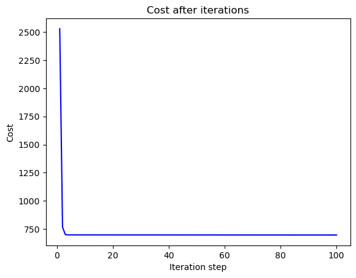

```python
# xaxis = np.arange(1, len(J_hist) + 1)
xaxis = np.arange(1, 101)

plt.figure()

plt.title("Cost after iterations")
plt.xlabel("Iteration step")
plt.ylabel("Cost")
plt.plot(xaxis, J_hist[:100], color = 'blue')

plt.show()
```